# Risk Factor Analysis

## Outcome Variable

**Outcome Variable:** wasted

## Predictor Variables

**Intervention Variable:** birthwt

**Adjustment Set:**

- arm
- sex
- W_mage
- meducyrs
- feducyrs
- vagbrth
- single
- brthmon
- W_parity
- delta_W_mage
- delta_meducyrs
- delta_feducyrs
- delta_vagbrth
- delta_single
- delta_brthmon
- delta_W_parity

## Stratifying Variables

The analysis was stratified on these variable(s):

- agecat
- studyid
- country

## Data Summary

| agecat | studyid | country | birthwt | wasted | n_cell | n |
| --- | --- | --- | --- | --- | --- | --- |
| Birth | ki0047075b-MAL-ED | BANGLADESH | Normal or high birthweight | 0 | 177 | 241 |
| Birth | ki0047075b-MAL-ED | BANGLADESH | Normal or high birthweight | 1 | 25 | 241 |
| Birth | ki0047075b-MAL-ED | BANGLADESH | Low birth weight | 0 | 24 | 241 |
| Birth | ki0047075b-MAL-ED | BANGLADESH | Low birth weight | 1 | 15 | 241 |
| Birth | ki0047075b-MAL-ED | BRAZIL | Normal or high birthweight | 0 | 174 | 183 |
| Birth | ki0047075b-MAL-ED | BRAZIL | Normal or high birthweight | 1 | 5 | 183 |
| Birth | ki0047075b-MAL-ED | BRAZIL | Low birth weight | 0 | 3 | 183 |
| Birth | ki0047075b-MAL-ED | BRAZIL | Low birth weight | 1 | 1 | 183 |
| Birth | ki0047075b-MAL-ED | INDIA | Normal or high birthweight | 0 | 152 | 203 |
| Birth | ki0047075b-MAL-ED | INDIA | Normal or high birthweight | 1 | 19 | 203 |
| Birth | ki0047075b-MAL-ED | INDIA | Low birth weight | 0 | 18 | 203 |
| Birth | ki0047075b-MAL-ED | INDIA | Low birth weight | 1 | 14 | 203 |
| Birth | ki0047075b-MAL-ED | NEPAL | Normal or high birthweight | 0 | 142 | 168 |
| Birth | ki0047075b-MAL-ED | NEPAL | Normal or high birthweight | 1 | 13 | 168 |
| Birth | ki0047075b-MAL-ED | NEPAL | Low birth weight | 0 | 6 | 168 |
| Birth | ki0047075b-MAL-ED | NEPAL | Low birth weight | 1 | 7 | 168 |
| Birth | ki0047075b-MAL-ED | PERU | Normal or high birthweight | 0 | 260 | 279 |
| Birth | ki0047075b-MAL-ED | PERU | Normal or high birthweight | 1 | 5 | 279 |
| Birth | ki0047075b-MAL-ED | PERU | Low birth weight | 0 | 13 | 279 |
| Birth | ki0047075b-MAL-ED | PERU | Low birth weight | 1 | 1 | 279 |
| Birth | ki0047075b-MAL-ED | SOUTH AFRICA | Normal or high birthweight | 0 | 231 | 258 |
| Birth | ki0047075b-MAL-ED | SOUTH AFRICA | Normal or high birthweight | 1 | 13 | 258 |
| Birth | ki0047075b-MAL-ED | SOUTH AFRICA | Low birth weight | 0 | 9 | 258 |
| Birth | ki0047075b-MAL-ED | SOUTH AFRICA | Low birth weight | 1 | 5 | 258 |
| Birth | ki0047075b-MAL-ED | TANZANIA, UNITED REPUBLIC OF | Normal or high birthweight | 0 | 112 | 118 |
| Birth | ki0047075b-MAL-ED | TANZANIA, UNITED REPUBLIC OF | Normal or high birthweight | 1 | 1 | 118 |
| Birth | ki0047075b-MAL-ED | TANZANIA, UNITED REPUBLIC OF | Low birth weight | 0 | 4 | 118 |
| Birth | ki0047075b-MAL-ED | TANZANIA, UNITED REPUBLIC OF | Low birth weight | 1 | 1 | 118 |
| Birth | ki1000108-CMC-V-BCS-2002 | INDIA | Normal or high birthweight | 0 | 70 | 88 |
| Birth | ki1000108-CMC-V-BCS-2002 | INDIA | Normal or high birthweight | 1 | 9 | 88 |

[output cut: 286 more lines]

The following strata were considered:

- agecat: 24 months, studyid: ki0047075b-MAL-ED, country: BANGLADESH
- agecat: 24 months, studyid: ki0047075b-MAL-ED, country: BRAZIL
- agecat: 24 months, studyid: ki0047075b-MAL-ED, country: INDIA
- agecat: 24 months, studyid: ki0047075b-MAL-ED, country: NEPAL
- agecat: 24 months, studyid: ki0047075b-MAL-ED, country: PERU
- agecat: 24 months, studyid: ki0047075b-MAL-ED, country: SOUTH AFRICA
- agecat: 24 months, studyid: ki0047075b-MAL-ED, country: TANZANIA, UNITED REPUBLIC OF
- agecat: 24 months, studyid: ki1000108-CMC-V-BCS-2002, country: INDIA
- agecat: 24 months, studyid: ki1000108-IRC, country: INDIA
- agecat: 24 months, studyid: ki1017093-NIH-Birth, country: BANGLADESH
- agecat: 24 months, studyid: ki1017093b-PROVIDE, country: BANGLADESH
- agecat: 24 months, studyid: ki1017093c-NIH-Crypto, country: BANGLADESH
- agecat: 24 months, studyid: ki1066203-TanzaniaChild2, country: TANZANIA, UNITED REPUBLIC OF
- agecat: 24 months, studyid: ki1101329-Keneba, country: GAMBIA
- agecat: 24 months, studyid: ki1114097-CMIN, country: BANGLADESH
- agecat: 24 months, studyid: ki1114097-CMIN, country: PERU
- agecat: 24 months, studyid: ki1114097-CONTENT, country: PERU
- agecat: 24 months, studyid: ki1119695-PROBIT, country: BELARUS
- agecat: 24 months, studyid: ki1126311-ZVITAMBO, country: ZIMBABWE
- agecat: 24 months, studyid: ki1135781-COHORTS, country: GUATEMALA
- agecat: 24 months, studyid: ki1135781-COHORTS, country: INDIA
- agecat: 24 months, studyid: ki1135781-COHORTS, country: PHILIPPINES
- agecat: 24 months, studyid: kiGH5241-JiVitA-3, country: BANGLADESH
- agecat: 24 months, studyid: kiGH5241-JiVitA-4, country: BANGLADESH
- agecat: 6 months, studyid: ki0047075b-MAL-ED, country: BANGLADESH
- agecat: 6 months, studyid: ki0047075b-MAL-ED, country: BRAZIL
- agecat: 6 months, studyid: ki0047075b-MAL-ED, country: INDIA
- agecat: 6 months, studyid: ki0047075b-MAL-ED, country: NEPAL
- agecat: 6 months, studyid: ki0047075b-MAL-ED, country: PERU
- agecat: 6 months, studyid: ki0047075b-MAL-ED, country: SOUTH AFRICA
- agecat: 6 months, studyid: ki0047075b-MAL-ED, country: TANZANIA, UNITED REPUBLIC OF
- agecat: 6 months, studyid: ki1000108-CMC-V-BCS-2002, country: INDIA
- agecat: 6 months, studyid: ki1000108-IRC, country: INDIA
- agecat: 6 months, studyid: ki1000109-EE, country: PAKISTAN
- agecat: 6 months, studyid: ki1000109-ResPak, country: PAKISTAN
- agecat: 6 months, studyid: ki1000304b-SAS-CompFeed, country: INDIA
- agecat: 6 months, studyid: ki1017093-NIH-Birth, country: BANGLADESH
- agecat: 6 months, studyid: ki1017093b-PROVIDE, country: BANGLADESH
- agecat: 6 months, studyid: ki1017093c-NIH-Crypto, country: BANGLADESH
- agecat: 6 months, studyid: ki1066203-TanzaniaChild2, country: TANZANIA, UNITED REPUBLIC OF
- agecat: 6 months, studyid: ki1101329-Keneba, country: GAMBIA
- agecat: 6 months, studyid: ki1114097-CMIN, country: BANGLADESH
- agecat: 6 months, studyid: ki1114097-CMIN, country: BRAZIL
- agecat: 6 months, studyid: ki1114097-CMIN, country: GUINEA-BISSAU
- agecat: 6 months, studyid: ki1114097-CMIN, country: PERU
- agecat: 6 months, studyid: ki1114097-CONTENT, country: PERU
- agecat: 6 months, studyid: ki1119695-PROBIT, country: BELARUS
- agecat: 6 months, studyid: ki1126311-ZVITAMBO, country: ZIMBABWE
- agecat: 6 months, studyid: ki1135781-COHORTS, country: GUATEMALA
- agecat: 6 months, studyid: ki1135781-COHORTS, country: INDIA
- agecat: 6 months, studyid: ki1135781-COHORTS, country: PHILIPPINES
- agecat: 6 months, studyid: kiGH5241-JiVitA-3, country: BANGLADESH
- agecat: 6 months, studyid: kiGH5241-JiVitA-4, country: BANGLADESH
- agecat: Birth, studyid: ki0047075b-MAL-ED, country: BANGLADESH
- agecat: Birth, studyid: ki0047075b-MAL-ED, country: BRAZIL
- agecat: Birth, studyid: ki0047075b-MAL-ED, country: INDIA
- agecat: Birth, studyid: ki0047075b-MAL-ED, country: NEPAL
- agecat: Birth, studyid: ki0047075b-MAL-ED, country: PERU
- agecat: Birth, studyid: ki0047075b-MAL-ED, country: SOUTH AFRICA
- agecat: Birth, studyid: ki0047075b-MAL-ED, country: TANZANIA, UNITED REPUBLIC OF
- agecat: Birth, studyid: ki1000108-CMC-V-BCS-2002, country: INDIA
- agecat: Birth, studyid: ki1000108-IRC, country: INDIA
- agecat: Birth, studyid: ki1000109-EE, country: PAKISTAN
- agecat: Birth, studyid: ki1000109-ResPak, country: PAKISTAN
- agecat: Birth, studyid: ki1000304b-SAS-CompFeed, country: INDIA
- agecat: Birth, studyid: ki1017093-NIH-Birth, country: BANGLADESH
- agecat: Birth, studyid: ki1017093c-NIH-Crypto, country: BANGLADESH
- agecat: Birth, studyid: ki1101329-Keneba, country: GAMBIA
- agecat: Birth, studyid: ki1114097-CMIN, country: BANGLADESH
- agecat: Birth, studyid: ki1114097-CMIN, country: BRAZIL
- agecat: Birth, studyid: ki1114097-CMIN, country: PERU
- agecat: Birth, studyid: ki1114097-CONTENT, country: PERU
- agecat: Birth, studyid: ki1119695-PROBIT, country: BELARUS
- agecat: Birth, studyid: ki1126311-ZVITAMBO, country: ZIMBABWE
- agecat: Birth, studyid: ki1135781-COHORTS, country: GUATEMALA
- agecat: Birth, studyid: ki1135781-COHORTS, country: INDIA
- agecat: Birth, studyid: ki1135781-COHORTS, country: PHILIPPINES
- agecat: Birth, studyid: kiGH5241-JiVitA-3, country: BANGLADESH
- agecat: Birth, studyid: kiGH5241-JiVitA-4, country: BANGLADESH

### Dropped Strata

Some strata were dropped due to rare outcomes:

- agecat: Birth, studyid: ki0047075b-MAL-ED, country: BRAZIL
- agecat: Birth, studyid: ki0047075b-MAL-ED, country: PERU
- agecat: Birth, studyid: ki0047075b-MAL-ED, country: TANZANIA, UNITED REPUBLIC OF
- agecat: Birth, studyid: ki1000108-CMC-V-BCS-2002, country: INDIA
- agecat: Birth, studyid: ki1000109-EE, country: PAKISTAN
- agecat: Birth, studyid: ki1000109-ResPak, country: PAKISTAN
- agecat: Birth, studyid: ki1000304b-SAS-CompFeed, country: INDIA
- agecat: Birth, studyid: ki1017093-NIH-Birth, country: BANGLADESH
- agecat: Birth, studyid: ki1017093c-NIH-Crypto, country: BANGLADESH
- agecat: Birth, studyid: ki1114097-CMIN, country: BANGLADESH
- agecat: Birth, studyid: ki1114097-CMIN, country: BRAZIL
- agecat: Birth, studyid: ki1114097-CMIN, country: PERU
- agecat: Birth, studyid: ki1114097-CONTENT, country: PERU
- agecat: Birth, studyid: ki1119695-PROBIT, country: BELARUS
- agecat: 6 months, studyid: ki0047075b-MAL-ED, country: BANGLADESH
- agecat: 6 months, studyid: ki0047075b-MAL-ED, country: BRAZIL
- agecat: 6 months, studyid: ki0047075b-MAL-ED, country: INDIA
- agecat: 6 months, studyid: ki0047075b-MAL-ED, country: NEPAL
- agecat: 6 months, studyid: ki0047075b-MAL-ED, country: PERU
- agecat: 6 months, studyid: ki0047075b-MAL-ED, country: SOUTH AFRICA
- agecat: 6 months, studyid: ki0047075b-MAL-ED, country: TANZANIA, UNITED REPUBLIC OF
- agecat: 6 months, studyid: ki1000109-ResPak, country: PAKISTAN
- agecat: 6 months, studyid: ki1066203-TanzaniaChild2, country: TANZANIA, UNITED REPUBLIC OF
- agecat: 6 months, studyid: ki1114097-CMIN, country: BANGLADESH
- agecat: 6 months, studyid: ki1114097-CMIN, country: BRAZIL
- agecat: 6 months, studyid: ki1114097-CMIN, country: GUINEA-BISSAU
- agecat: 6 months, studyid: ki1114097-CMIN, country: PERU
- agecat: 6 months, studyid: ki1114097-CONTENT, country: PERU
- agecat: 6 months, studyid: ki1119695-PROBIT, country: BELARUS
- agecat: 6 months, studyid: ki1135781-COHORTS, country: GUATEMALA
- agecat: 24 months, studyid: ki0047075b-MAL-ED, country: BANGLADESH
- agecat: 24 months, studyid: ki0047075b-MAL-ED, country: BRAZIL
- agecat: 24 months, studyid: ki0047075b-MAL-ED, country: NEPAL
- agecat: 24 months, studyid: ki0047075b-MAL-ED, country: PERU
- agecat: 24 months, studyid: ki0047075b-MAL-ED, country: SOUTH AFRICA
- agecat: 24 months, studyid: ki0047075b-MAL-ED, country: TANZANIA, UNITED REPUBLIC OF
- agecat: 24 months, studyid: ki1066203-TanzaniaChild2, country: TANZANIA, UNITED REPUBLIC OF
- agecat: 24 months, studyid: ki1114097-CMIN, country: BANGLADESH
- agecat: 24 months, studyid: ki1114097-CMIN, country: PERU
- agecat: 24 months, studyid: ki1114097-CONTENT, country: PERU
- agecat: 24 months, studyid: ki1119695-PROBIT, country: BELARUS

## Methods Detail

We’re interested in the causal parameters $E[Y_a]$ for all values of $a \in \mathcal{A}$. These parameters represent the mean outcome if, possibly contrary to fact, we intervened to set all units to have $A=a$. Under the randomization and positivity assumptions, these are identified by the statistical parameters $\psi_a=E_W[E_{Y|A,W}(Y|A=a,W)]$. In addition, we’re interested in the mean of $Y$, $E[Y]$ under no intervention (the observed mean). We will estimate these parameters by using SuperLearner to fit the relevant likelihood factors – $E_{Y|A,W}(Y|A=a,W)$ and $p(A=a|W)$, and then updating our likelihood fit using a joint TMLE.

For unadjusted analyses ($W=\{\}$), initial likelihoods were estimated using Lrnr_glm to estimate the simple $E(Y|A)$ and Lrnr_mean to estimate $p(A)$. For adjusted analyses, a small library containing Lrnr_glmnet, Lrnr_xgboost, and Lrnr_mean was used.

Having estimated these parameters, we will then use the delta method to estimate relative risks and attributable risks relative to a prespecified baseline level of $A$.

# Results Detail

## Results Plots

[figure not shown]

[figure not shown]

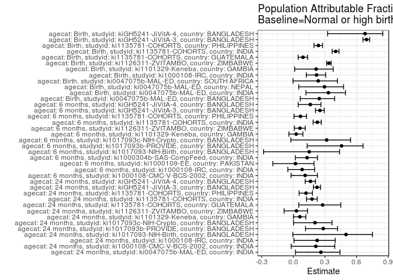

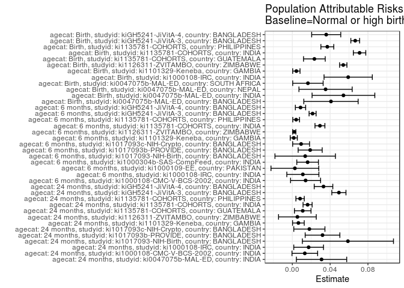

## Results Table

### Parameter: TSM

| agecat | studyid | country | intervention_level | baseline_level | estimate | ci_lower | ci_upper |
| --- | --- | --- | --- | --- | --- | --- | --- |
| Birth | ki0047075b-MAL-ED | BANGLADESH | Normal or high birthweight | NA | 0.1250862 | 0.0796355 | 0.1705369 |
| Birth | ki0047075b-MAL-ED | BANGLADESH | Low birth weight | NA | 0.4456858 | 0.2907004 | 0.6006712 |
| Birth | ki0047075b-MAL-ED | INDIA | Normal or high birthweight | NA | 0.1084692 | 0.0611967 | 0.1557418 |
| Birth | ki0047075b-MAL-ED | INDIA | Low birth weight | NA | 0.3779219 | 0.2035536 | 0.5522902 |
| Birth | ki0047075b-MAL-ED | NEPAL | Normal or high birthweight | NA | 0.0838710 | 0.0401024 | 0.1276396 |
| Birth | ki0047075b-MAL-ED | NEPAL | Low birth weight | NA | 0.5384615 | 0.2666586 | 0.8102645 |
| Birth | ki0047075b-MAL-ED | SOUTH AFRICA | Normal or high birthweight | NA | 0.0532787 | 0.0250439 | 0.0815135 |
| Birth | ki0047075b-MAL-ED | SOUTH AFRICA | Low birth weight | NA | 0.3571429 | 0.1056616 | 0.6086241 |
| Birth | ki1000108-IRC | INDIA | Normal or high birthweight | NA | 0.2091274 | 0.1626613 | 0.2555934 |
| Birth | ki1000108-IRC | INDIA | Low birth weight | NA | 0.6610676 | 0.5130857 | 0.8090495 |
| Birth | ki1101329-Keneba | GAMBIA | Normal or high birthweight | NA | 0.0154202 | 0.0087121 | 0.0221283 |
| Birth | ki1101329-Keneba | GAMBIA | Low birth weight | NA | 0.0634921 | 0.0208998 | 0.1060843 |
| Birth | ki1126311-ZVITAMBO | ZIMBABWE | Normal or high birthweight | NA | 0.1056073 | 0.1000108 | 0.1112038 |
| Birth | ki1126311-ZVITAMBO | ZIMBABWE | Low birth weight | NA | 0.6379949 | 0.6113144 | 0.6646754 |
| Birth | ki1135781-COHORTS | GUATEMALA | Normal or high birthweight | NA | 0.2306359 | 0.1994490 | 0.2618227 |
| Birth | ki1135781-COHORTS | GUATEMALA | Low birth weight | NA | 0.5903899 | 0.4527828 | 0.7279970 |
| Birth | ki1135781-COHORTS | INDIA | Normal or high birthweight | NA | 0.1058417 | 0.0974571 | 0.1142262 |
| Birth | ki1135781-COHORTS | INDIA | Low birth weight | NA | 0.5411150 | 0.5102792 | 0.5719508 |
| Birth | ki1135781-COHORTS | PHILIPPINES | Normal or high birthweight | NA | 0.1185450 | 0.1063149 | 0.1307751 |
| Birth | ki1135781-COHORTS | PHILIPPINES | Low birth weight | NA | 0.6285382 | 0.5629209 | 0.6941554 |
| Birth | kiGH5241-JiVitA-3 | BANGLADESH | Normal or high birthweight | NA | 0.0293265 | 0.0258739 | 0.0327791 |
| Birth | kiGH5241-JiVitA-3 | BANGLADESH | Low birth weight | NA | 0.2514084 | 0.2375475 | 0.2652692 |
| Birth | kiGH5241-JiVitA-4 | BANGLADESH | Normal or high birthweight | NA | 0.0168539 | 0.0014406 | 0.0322673 |
| Birth | kiGH5241-JiVitA-4 | BANGLADESH | Low birth weight | NA | 0.1812081 | 0.1157680 | 0.2466481 |
| 6 months | ki1000108-CMC-V-BCS-2002 | INDIA | Normal or high birthweight | NA | 0.1109751 | 0.0767484 | 0.1452018 |
| 6 months | ki1000108-CMC-V-BCS-2002 | INDIA | Low birth weight | NA | 0.2396888 | 0.1104724 | 0.3689052 |
| 6 months | ki1000108-IRC | INDIA | Normal or high birthweight | NA | 0.1218765 | 0.0869874 | 0.1567656 |
| 6 months | ki1000108-IRC | INDIA | Low birth weight | NA | 0.2067796 | 0.1126543 | 0.3009050 |
| 6 months | ki1000109-EE | PAKISTAN | Normal or high birthweight | NA | 0.1276332 | 0.0858538 | 0.1694125 |
| 6 months | ki1000109-EE | PAKISTAN | Low birth weight | NA | 0.1413472 | 0.0823160 | 0.2003784 |
| 6 months | ki1000304b-SAS-CompFeed | INDIA | Normal or high birthweight | NA | 0.1077042 | 0.0770646 | 0.1383437 |
| 6 months | ki1000304b-SAS-CompFeed | INDIA | Low birth weight | NA | 0.1742688 | 0.1426657 | 0.2058719 |
| 6 months | ki1017093-NIH-Birth | BANGLADESH | Normal or high birthweight | NA | 0.0762712 | 0.0282445 | 0.1242979 |
| 6 months | ki1017093-NIH-Birth | BANGLADESH | Low birth weight | NA | 0.1166667 | 0.0352091 | 0.1981243 |
| 6 months | ki1017093b-PROVIDE | BANGLADESH | Normal or high birthweight | NA | 0.0223589 | 0.0084749 | 0.0362430 |
| 6 months | ki1017093b-PROVIDE | BANGLADESH | Low birth weight | NA | 0.1018026 | 0.0524751 | 0.1511301 |
| 6 months | ki1017093c-NIH-Crypto | BANGLADESH | Normal or high birthweight | NA | 0.0200837 | 0.0082786 | 0.0318888 |
| 6 months | ki1017093c-NIH-Crypto | BANGLADESH | Low birth weight | NA | 0.0611002 | 0.0256585 | 0.0965418 |
| 6 months | ki1101329-Keneba | GAMBIA | Normal or high birthweight | NA | 0.0547089 | 0.0434535 | 0.0659643 |
| 6 months | ki1101329-Keneba | GAMBIA | Low birth weight | NA | 0.0725630 | 0.0298356 | 0.1152903 |
| 6 months | ki1126311-ZVITAMBO | ZIMBABWE | Normal or high birthweight | NA | 0.0300312 | 0.0260845 | 0.0339779 |
| 6 months | ki1126311-ZVITAMBO | ZIMBABWE | Low birth weight | NA | 0.0460443 | 0.0333388 | 0.0587497 |
| 6 months | ki1135781-COHORTS | INDIA | Normal or high birthweight | NA | 0.0990691 | 0.0907809 | 0.1073572 |
| 6 months | ki1135781-COHORTS | INDIA | Low birth weight | NA | 0.2448575 | 0.2210400 | 0.2686751 |
| 6 months | ki1135781-COHORTS | PHILIPPINES | Normal or high birthweight | NA | 0.0552704 | 0.0461509 | 0.0643899 |
| 6 months | ki1135781-COHORTS | PHILIPPINES | Low birth weight | NA | 0.0982363 | 0.0618662 | 0.1346064 |
| 6 months | kiGH5241-JiVitA-3 | BANGLADESH | Normal or high birthweight | NA | 0.0633592 | 0.0582917 | 0.0684268 |
| 6 months | kiGH5241-JiVitA-3 | BANGLADESH | Low birth weight | NA | 0.1230058 | 0.1136247 | 0.1323870 |
| 6 months | kiGH5241-JiVitA-4 | BANGLADESH | Normal or high birthweight | NA | 0.0449994 | 0.0335785 | 0.0564204 |
| 6 months | kiGH5241-JiVitA-4 | BANGLADESH | Low birth weight | NA | 0.0782911 | 0.0604947 | 0.0960876 |
| 24 months | ki0047075b-MAL-ED | INDIA | Normal or high birthweight | NA | 0.0872733 | 0.0465381 | 0.1280085 |
| 24 months | ki0047075b-MAL-ED | INDIA | Low birth weight | NA | 0.2848085 | 0.1267413 | 0.4428758 |
| 24 months | ki1000108-CMC-V-BCS-2002 | INDIA | Normal or high birthweight | NA | 0.0486322 | 0.0253582 | 0.0719062 |
| 24 months | ki1000108-CMC-V-BCS-2002 | INDIA | Low birth weight | NA | 0.1627907 | 0.0522989 | 0.2732825 |
| 24 months | ki1000108-IRC | INDIA | Normal or high birthweight | NA | 0.0589242 | 0.0337762 | 0.0840722 |
| 24 months | ki1000108-IRC | INDIA | Low birth weight | NA | 0.1540461 | 0.0646190 | 0.2434731 |
| 24 months | ki1017093-NIH-Birth | BANGLADESH | Normal or high birthweight | NA | 0.0588235 | 0.0086179 | 0.1090291 |
| 24 months | ki1017093-NIH-Birth | BANGLADESH | Low birth weight | NA | 0.2156863 | 0.1023884 | 0.3289841 |
| 24 months | ki1017093b-PROVIDE | BANGLADESH | Normal or high birthweight | NA | 0.0805148 | 0.0551566 | 0.1058730 |
| 24 months | ki1017093b-PROVIDE | BANGLADESH | Low birth weight | NA | 0.2413867 | 0.1733502 | 0.3094233 |
| 24 months | ki1017093c-NIH-Crypto | BANGLADESH | Normal or high birthweight | NA | 0.0695336 | 0.0441132 | 0.0949541 |
| 24 months | ki1017093c-NIH-Crypto | BANGLADESH | Low birth weight | NA | 0.1389458 | 0.0773325 | 0.2005592 |
| 24 months | ki1101329-Keneba | GAMBIA | Normal or high birthweight | NA | 0.0973461 | 0.0812188 | 0.1134733 |
| 24 months | ki1101329-Keneba | GAMBIA | Low birth weight | NA | 0.1553160 | 0.0936891 | 0.2169429 |
| 24 months | ki1126311-ZVITAMBO | ZIMBABWE | Normal or high birthweight | NA | 0.1751553 | 0.1340061 | 0.2163045 |
| 24 months | ki1126311-ZVITAMBO | ZIMBABWE | Low birth weight | NA | 0.1907762 | 0.1086760 | 0.2728765 |
| 24 months | ki1135781-COHORTS | GUATEMALA | Normal or high birthweight | NA | 0.0285714 | 0.0151749 | 0.0419679 |
| 24 months | ki1135781-COHORTS | GUATEMALA | Low birth weight | NA | 0.1451613 | 0.0574106 | 0.2329120 |
| 24 months | ki1135781-COHORTS | INDIA | Normal or high birthweight | NA | 0.0747147 | 0.0664586 | 0.0829709 |
| 24 months | ki1135781-COHORTS | INDIA | Low birth weight | NA | 0.1634490 | 0.1394720 | 0.1874261 |
| 24 months | ki1135781-COHORTS | PHILIPPINES | Normal or high birthweight | NA | 0.0598424 | 0.0498946 | 0.0697902 |
| 24 months | ki1135781-COHORTS | PHILIPPINES | Low birth weight | NA | 0.1550775 | 0.1069680 | 0.2031870 |
| 24 months | kiGH5241-JiVitA-3 | BANGLADESH | Normal or high birthweight | NA | 0.1694415 | 0.1582263 | 0.1806568 |
| 24 months | kiGH5241-JiVitA-3 | BANGLADESH | Low birth weight | NA | 0.3016645 | 0.2846549 | 0.3186742 |
| 24 months | kiGH5241-JiVitA-4 | BANGLADESH | Normal or high birthweight | NA | 0.1694140 | 0.1527082 | 0.1861197 |
| 24 months | kiGH5241-JiVitA-4 | BANGLADESH | Low birth weight | NA | 0.2939239 | 0.2616295 | 0.3262184 |

### Parameter: E(Y)

| agecat | studyid | country | intervention_level | baseline_level | estimate | ci_lower | ci_upper |
| --- | --- | --- | --- | --- | --- | --- | --- |
| Birth | ki0047075b-MAL-ED | BANGLADESH | NA | NA | 0.1659751 | 0.1189041 | 0.2130461 |
| Birth | ki0047075b-MAL-ED | INDIA | NA | NA | 0.1625616 | 0.1116803 | 0.2134428 |
| Birth | ki0047075b-MAL-ED | NEPAL | NA | NA | 0.1190476 | 0.0699312 | 0.1681640 |
| Birth | ki0047075b-MAL-ED | SOUTH AFRICA | NA | NA | 0.0697674 | 0.0386213 | 0.1009135 |
| Birth | ki1000108-IRC | INDIA | NA | NA | 0.2682216 | 0.2212677 | 0.3151755 |
| Birth | ki1101329-Keneba | GAMBIA | NA | NA | 0.0196767 | 0.0124580 | 0.0268954 |
| Birth | ki1126311-ZVITAMBO | ZIMBABWE | NA | NA | 0.1594921 | 0.1531776 | 0.1658066 |
| Birth | ki1135781-COHORTS | GUATEMALA | NA | NA | 0.2539683 | 0.2229196 | 0.2850169 |
| Birth | ki1135781-COHORTS | INDIA | NA | NA | 0.1769740 | 0.1674681 | 0.1864799 |
| Birth | ki1135781-COHORTS | PHILIPPINES | NA | NA | 0.1555709 | 0.1423748 | 0.1687670 |
| Birth | kiGH5241-JiVitA-3 | BANGLADESH | NA | NA | 0.0958686 | 0.0906699 | 0.1010673 |
| Birth | kiGH5241-JiVitA-4 | BANGLADESH | NA | NA | 0.0527086 | 0.0336587 | 0.0717585 |
| 6 months | ki1000108-CMC-V-BCS-2002 | INDIA | NA | NA | 0.1250000 | 0.0911644 | 0.1588356 |
| 6 months | ki1000108-IRC | INDIA | NA | NA | 0.1330049 | 0.0999328 | 0.1660771 |
| 6 months | ki1000109-EE | PAKISTAN | NA | NA | 0.1303191 | 0.0962457 | 0.1643926 |
| 6 months | ki1000304b-SAS-CompFeed | INDIA | NA | NA | 0.1238671 | 0.0990601 | 0.1486741 |
| 6 months | ki1017093-NIH-Birth | BANGLADESH | NA | NA | 0.0898876 | 0.0477511 | 0.1320242 |
| 6 months | ki1017093b-PROVIDE | BANGLADESH | NA | NA | 0.0412371 | 0.0250690 | 0.0574052 |
| 6 months | ki1017093c-NIH-Crypto | BANGLADESH | NA | NA | 0.0293706 | 0.0169860 | 0.0417552 |
| 6 months | ki1101329-Keneba | GAMBIA | NA | NA | 0.0562319 | 0.0453575 | 0.0671062 |
| 6 months | ki1126311-ZVITAMBO | ZIMBABWE | NA | NA | 0.0320622 | 0.0282569 | 0.0358675 |
| 6 months | ki1135781-COHORTS | INDIA | NA | NA | 0.1282790 | 0.1199892 | 0.1365687 |
| 6 months | ki1135781-COHORTS | PHILIPPINES | NA | NA | 0.0593093 | 0.0503382 | 0.0682804 |
| 6 months | kiGH5241-JiVitA-3 | BANGLADESH | NA | NA | 0.0847894 | 0.0799656 | 0.0896132 |
| 6 months | kiGH5241-JiVitA-4 | BANGLADESH | NA | NA | 0.0536465 | 0.0439582 | 0.0633347 |
| 24 months | ki0047075b-MAL-ED | INDIA | NA | NA | 0.1181818 | 0.0754264 | 0.1609372 |
| 24 months | ki1000108-CMC-V-BCS-2002 | INDIA | NA | NA | 0.0618280 | 0.0373207 | 0.0863352 |
| 24 months | ki1000108-IRC | INDIA | NA | NA | 0.0761671 | 0.0503644 | 0.1019698 |
| 24 months | ki1017093-NIH-Birth | BANGLADESH | NA | NA | 0.1176471 | 0.0632979 | 0.1719962 |
| 24 months | ki1017093b-PROVIDE | BANGLADESH | NA | NA | 0.1124567 | 0.0866788 | 0.1382347 |
| 24 months | ki1017093c-NIH-Crypto | BANGLADESH | NA | NA | 0.0875486 | 0.0630907 | 0.1120065 |
| 24 months | ki1101329-Keneba | GAMBIA | NA | NA | 0.1037604 | 0.0879825 | 0.1195384 |
| 24 months | ki1126311-ZVITAMBO | ZIMBABWE | NA | NA | 0.1805226 | 0.1437387 | 0.2173065 |
| 24 months | ki1135781-COHORTS | GUATEMALA | NA | NA | 0.0395738 | 0.0246551 | 0.0544926 |
| 24 months | ki1135781-COHORTS | INDIA | NA | NA | 0.0908525 | 0.0827390 | 0.0989661 |
| 24 months | ki1135781-COHORTS | PHILIPPINES | NA | NA | 0.0680498 | 0.0579935 | 0.0781061 |
| 24 months | kiGH5241-JiVitA-3 | BANGLADESH | NA | NA | 0.2187025 | 0.2087401 | 0.2286649 |
| 24 months | kiGH5241-JiVitA-4 | BANGLADESH | NA | NA | 0.2024018 | 0.1878193 | 0.2169843 |

### Parameter: RR

| agecat | studyid | country | intervention_level | baseline_level | estimate | ci_lower | ci_upper |
| --- | --- | --- | --- | --- | --- | --- | --- |
| Birth | ki0047075b-MAL-ED | BANGLADESH | Normal or high birthweight | Normal or high birthweight | 1.000000 | 1.0000000 | 1.000000 |
| Birth | ki0047075b-MAL-ED | BANGLADESH | Low birth weight | Normal or high birthweight | 3.563029 | 2.1434366 | 5.922814 |
| Birth | ki0047075b-MAL-ED | INDIA | Normal or high birthweight | Normal or high birthweight | 1.000000 | 1.0000000 | 1.000000 |
| Birth | ki0047075b-MAL-ED | INDIA | Low birth weight | Normal or high birthweight | 3.484139 | 1.8505859 | 6.559664 |
| Birth | ki0047075b-MAL-ED | NEPAL | Normal or high birthweight | Normal or high birthweight | 1.000000 | 1.0000000 | 1.000000 |
| Birth | ki0047075b-MAL-ED | NEPAL | Low birth weight | Normal or high birthweight | 6.420118 | 3.1061893 | 13.269610 |
| Birth | ki0047075b-MAL-ED | SOUTH AFRICA | Normal or high birthweight | Normal or high birthweight | 1.000000 | 1.0000000 | 1.000000 |
| Birth | ki0047075b-MAL-ED | SOUTH AFRICA | Low birth weight | Normal or high birthweight | 6.703297 | 2.7768391 | 16.181775 |
| Birth | ki1000108-IRC | INDIA | Normal or high birthweight | Normal or high birthweight | 1.000000 | 1.0000000 | 1.000000 |
| Birth | ki1000108-IRC | INDIA | Low birth weight | Normal or high birthweight | 3.161077 | 2.3035956 | 4.337743 |
| Birth | ki1101329-Keneba | GAMBIA | Normal or high birthweight | Normal or high birthweight | 1.000000 | 1.0000000 | 1.000000 |
| Birth | ki1101329-Keneba | GAMBIA | Low birth weight | Normal or high birthweight | 4.117460 | 1.8509561 | 9.159309 |
| Birth | ki1126311-ZVITAMBO | ZIMBABWE | Normal or high birthweight | Normal or high birthweight | 1.000000 | 1.0000000 | 1.000000 |
| Birth | ki1126311-ZVITAMBO | ZIMBABWE | Low birth weight | Normal or high birthweight | 6.041202 | 5.6468482 | 6.463095 |
| Birth | ki1135781-COHORTS | GUATEMALA | Normal or high birthweight | Normal or high birthweight | 1.000000 | 1.0000000 | 1.000000 |
| Birth | ki1135781-COHORTS | GUATEMALA | Low birth weight | Normal or high birthweight | 2.559836 | 1.9548838 | 3.351994 |
| Birth | ki1135781-COHORTS | INDIA | Normal or high birthweight | Normal or high birthweight | 1.000000 | 1.0000000 | 1.000000 |
| Birth | ki1135781-COHORTS | INDIA | Low birth weight | Normal or high birthweight | 5.112495 | 4.6369970 | 5.636753 |
| Birth | ki1135781-COHORTS | PHILIPPINES | Normal or high birthweight | Normal or high birthweight | 1.000000 | 1.0000000 | 1.000000 |
| Birth | ki1135781-COHORTS | PHILIPPINES | Low birth weight | Normal or high birthweight | 5.302107 | 4.5786031 | 6.139939 |
| Birth | kiGH5241-JiVitA-3 | BANGLADESH | Normal or high birthweight | Normal or high birthweight | 1.000000 | 1.0000000 | 1.000000 |
| Birth | kiGH5241-JiVitA-3 | BANGLADESH | Low birth weight | Normal or high birthweight | 8.572741 | 7.5273434 | 9.763324 |
| Birth | kiGH5241-JiVitA-4 | BANGLADESH | Normal or high birthweight | Normal or high birthweight | 1.000000 | 1.0000000 | 1.000000 |
| Birth | kiGH5241-JiVitA-4 | BANGLADESH | Low birth weight | Normal or high birthweight | 10.751677 | 4.0151639 | 28.790496 |
| 6 months | ki1000108-CMC-V-BCS-2002 | INDIA | Normal or high birthweight | Normal or high birthweight | 1.000000 | 1.0000000 | 1.000000 |
| 6 months | ki1000108-CMC-V-BCS-2002 | INDIA | Low birth weight | Normal or high birthweight | 2.159843 | 1.1602618 | 4.020578 |
| 6 months | ki1000108-IRC | INDIA | Normal or high birthweight | Normal or high birthweight | 1.000000 | 1.0000000 | 1.000000 |
| 6 months | ki1000108-IRC | INDIA | Low birth weight | Normal or high birthweight | 1.696632 | 0.9904896 | 2.906200 |
| 6 months | ki1000109-EE | PAKISTAN | Normal or high birthweight | Normal or high birthweight | 1.000000 | 1.0000000 | 1.000000 |
| 6 months | ki1000109-EE | PAKISTAN | Low birth weight | Normal or high birthweight | 1.107449 | 0.6506450 | 1.884964 |
| 6 months | ki1000304b-SAS-CompFeed | INDIA | Normal or high birthweight | Normal or high birthweight | 1.000000 | 1.0000000 | 1.000000 |
| 6 months | ki1000304b-SAS-CompFeed | INDIA | Low birth weight | Normal or high birthweight | 1.618032 | 1.1875026 | 2.204650 |
| 6 months | ki1017093-NIH-Birth | BANGLADESH | Normal or high birthweight | Normal or high birthweight | 1.000000 | 1.0000000 | 1.000000 |
| 6 months | ki1017093-NIH-Birth | BANGLADESH | Low birth weight | Normal or high birthweight | 1.529630 | 0.5973901 | 3.916648 |
| 6 months | ki1017093b-PROVIDE | BANGLADESH | Normal or high birthweight | Normal or high birthweight | 1.000000 | 1.0000000 | 1.000000 |
| 6 months | ki1017093b-PROVIDE | BANGLADESH | Low birth weight | Normal or high birthweight | 4.553105 | 2.0710723 | 10.009677 |
| 6 months | ki1017093c-NIH-Crypto | BANGLADESH | Normal or high birthweight | Normal or high birthweight | 1.000000 | 1.0000000 | 1.000000 |
| 6 months | ki1017093c-NIH-Crypto | BANGLADESH | Low birth weight | Normal or high birthweight | 3.042276 | 1.3339888 | 6.938171 |
| 6 months | ki1101329-Keneba | GAMBIA | Normal or high birthweight | Normal or high birthweight | 1.000000 | 1.0000000 | 1.000000 |
| 6 months | ki1101329-Keneba | GAMBIA | Low birth weight | Normal or high birthweight | 1.326348 | 0.7114579 | 2.472666 |
| 6 months | ki1126311-ZVITAMBO | ZIMBABWE | Normal or high birthweight | Normal or high birthweight | 1.000000 | 1.0000000 | 1.000000 |
| 6 months | ki1126311-ZVITAMBO | ZIMBABWE | Low birth weight | Normal or high birthweight | 1.533215 | 1.1293662 | 2.081475 |
| 6 months | ki1135781-COHORTS | INDIA | Normal or high birthweight | Normal or high birthweight | 1.000000 | 1.0000000 | 1.000000 |
| 6 months | ki1135781-COHORTS | INDIA | Low birth weight | Normal or high birthweight | 2.471584 | 2.1741656 | 2.809689 |
| 6 months | ki1135781-COHORTS | PHILIPPINES | Normal or high birthweight | Normal or high birthweight | 1.000000 | 1.0000000 | 1.000000 |
| 6 months | ki1135781-COHORTS | PHILIPPINES | Low birth weight | Normal or high birthweight | 1.777378 | 1.1850497 | 2.665772 |
| 6 months | kiGH5241-JiVitA-3 | BANGLADESH | Normal or high birthweight | Normal or high birthweight | 1.000000 | 1.0000000 | 1.000000 |
| 6 months | kiGH5241-JiVitA-3 | BANGLADESH | Low birth weight | Normal or high birthweight | 1.941403 | 1.7463483 | 2.158245 |
| 6 months | kiGH5241-JiVitA-4 | BANGLADESH | Normal or high birthweight | Normal or high birthweight | 1.000000 | 1.0000000 | 1.000000 |
| 6 months | kiGH5241-JiVitA-4 | BANGLADESH | Low birth weight | Normal or high birthweight | 1.739824 | 1.2368878 | 2.447262 |
| 24 months | ki0047075b-MAL-ED | INDIA | Normal or high birthweight | Normal or high birthweight | 1.000000 | 1.0000000 | 1.000000 |
| 24 months | ki0047075b-MAL-ED | INDIA | Low birth weight | Normal or high birthweight | 3.263410 | 1.5780456 | 6.748757 |
| 24 months | ki1000108-CMC-V-BCS-2002 | INDIA | Normal or high birthweight | Normal or high birthweight | 1.000000 | 1.0000000 | 1.000000 |
| 24 months | ki1000108-CMC-V-BCS-2002 | INDIA | Low birth weight | Normal or high birthweight | 3.347384 | 1.4589101 | 7.680376 |
| 24 months | ki1000108-IRC | INDIA | Normal or high birthweight | Normal or high birthweight | 1.000000 | 1.0000000 | 1.000000 |
| 24 months | ki1000108-IRC | INDIA | Low birth weight | Normal or high birthweight | 2.614309 | 1.2704843 | 5.379533 |
| 24 months | ki1017093-NIH-Birth | BANGLADESH | Normal or high birthweight | Normal or high birthweight | 1.000000 | 1.0000000 | 1.000000 |
| 24 months | ki1017093-NIH-Birth | BANGLADESH | Low birth weight | Normal or high birthweight | 3.666667 | 1.3459409 | 9.988882 |
| 24 months | ki1017093b-PROVIDE | BANGLADESH | Normal or high birthweight | Normal or high birthweight | 1.000000 | 1.0000000 | 1.000000 |
| 24 months | ki1017093b-PROVIDE | BANGLADESH | Low birth weight | Normal or high birthweight | 2.998042 | 1.9591568 | 4.587820 |
| 24 months | ki1017093c-NIH-Crypto | BANGLADESH | Normal or high birthweight | Normal or high birthweight | 1.000000 | 1.0000000 | 1.000000 |
| 24 months | ki1017093c-NIH-Crypto | BANGLADESH | Low birth weight | Normal or high birthweight | 1.998254 | 1.1240804 | 3.552253 |
| 24 months | ki1101329-Keneba | GAMBIA | Normal or high birthweight | Normal or high birthweight | 1.000000 | 1.0000000 | 1.000000 |
| 24 months | ki1101329-Keneba | GAMBIA | Low birth weight | Normal or high birthweight | 1.595503 | 1.0376905 | 2.453170 |
| 24 months | ki1126311-ZVITAMBO | ZIMBABWE | Normal or high birthweight | Normal or high birthweight | 1.000000 | 1.0000000 | 1.000000 |
| 24 months | ki1126311-ZVITAMBO | ZIMBABWE | Low birth weight | Normal or high birthweight | 1.089183 | 0.6667389 | 1.779287 |
| 24 months | ki1135781-COHORTS | GUATEMALA | Normal or high birthweight | Normal or high birthweight | 1.000000 | 1.0000000 | 1.000000 |
| 24 months | ki1135781-COHORTS | GUATEMALA | Low birth weight | Normal or high birthweight | 5.080645 | 2.3641232 | 10.918617 |
| 24 months | ki1135781-COHORTS | INDIA | Normal or high birthweight | Normal or high birthweight | 1.000000 | 1.0000000 | 1.000000 |
| 24 months | ki1135781-COHORTS | INDIA | Low birth weight | Normal or high birthweight | 2.187641 | 1.8212197 | 2.627785 |
| 24 months | ki1135781-COHORTS | PHILIPPINES | Normal or high birthweight | Normal or high birthweight | 1.000000 | 1.0000000 | 1.000000 |
| 24 months | ki1135781-COHORTS | PHILIPPINES | Low birth weight | Normal or high birthweight | 2.591432 | 1.8230131 | 3.683747 |
| 24 months | kiGH5241-JiVitA-3 | BANGLADESH | Normal or high birthweight | Normal or high birthweight | 1.000000 | 1.0000000 | 1.000000 |
| 24 months | kiGH5241-JiVitA-3 | BANGLADESH | Low birth weight | Normal or high birthweight | 1.780346 | 1.6368716 | 1.936396 |
| 24 months | kiGH5241-JiVitA-4 | BANGLADESH | Normal or high birthweight | Normal or high birthweight | 1.000000 | 1.0000000 | 1.000000 |
| 24 months | kiGH5241-JiVitA-4 | BANGLADESH | Low birth weight | Normal or high birthweight | 1.734945 | 1.4923497 | 2.016977 |

### Parameter: PAR

| agecat | studyid | country | intervention_level | baseline_level | estimate | ci_lower | ci_upper |
| --- | --- | --- | --- | --- | --- | --- | --- |
| Birth | ki0047075b-MAL-ED | BANGLADESH | Normal or high birthweight | NA | 0.0408889 | 0.0121471 | 0.0696307 |
| Birth | ki0047075b-MAL-ED | INDIA | Normal or high birthweight | NA | 0.0540923 | 0.0209058 | 0.0872789 |
| Birth | ki0047075b-MAL-ED | NEPAL | Normal or high birthweight | NA | 0.0351767 | 0.0070128 | 0.0633405 |
| Birth | ki0047075b-MAL-ED | SOUTH AFRICA | Normal or high birthweight | NA | 0.0164888 | 0.0003830 | 0.0325945 |
| Birth | ki1000108-IRC | INDIA | Normal or high birthweight | NA | 0.0590942 | 0.0335539 | 0.0846345 |
| Birth | ki1101329-Keneba | GAMBIA | Normal or high birthweight | NA | 0.0042565 | 0.0003733 | 0.0081398 |
| Birth | ki1126311-ZVITAMBO | ZIMBABWE | Normal or high birthweight | NA | 0.0538848 | 0.0500184 | 0.0577512 |
| Birth | ki1135781-COHORTS | GUATEMALA | Normal or high birthweight | NA | 0.0233324 | 0.0118415 | 0.0348233 |
| Birth | ki1135781-COHORTS | INDIA | Normal or high birthweight | NA | 0.0711323 | 0.0645499 | 0.0777147 |
| Birth | ki1135781-COHORTS | PHILIPPINES | Normal or high birthweight | NA | 0.0370259 | 0.0302075 | 0.0438443 |
| Birth | kiGH5241-JiVitA-3 | BANGLADESH | Normal or high birthweight | NA | 0.0665421 | 0.0618993 | 0.0711850 |
| Birth | kiGH5241-JiVitA-4 | BANGLADESH | Normal or high birthweight | NA | 0.0358547 | 0.0204662 | 0.0512432 |
| 6 months | ki1000108-CMC-V-BCS-2002 | INDIA | Normal or high birthweight | NA | 0.0140249 | -0.0018741 | 0.0299239 |
| 6 months | ki1000108-IRC | INDIA | Normal or high birthweight | NA | 0.0111284 | -0.0058457 | 0.0281025 |
| 6 months | ki1000109-EE | PAKISTAN | Normal or high birthweight | NA | 0.0026860 | -0.0226041 | 0.0279760 |
| 6 months | ki1000304b-SAS-CompFeed | INDIA | Normal or high birthweight | NA | 0.0161629 | 0.0047167 | 0.0276092 |
| 6 months | ki1017093-NIH-Birth | BANGLADESH | Normal or high birthweight | NA | 0.0136165 | -0.0183822 | 0.0456151 |
| 6 months | ki1017093b-PROVIDE | BANGLADESH | Normal or high birthweight | NA | 0.0188782 | 0.0061584 | 0.0315979 |
| 6 months | ki1017093c-NIH-Crypto | BANGLADESH | Normal or high birthweight | NA | 0.0092869 | 0.0003552 | 0.0182187 |
| 6 months | ki1101329-Keneba | GAMBIA | Normal or high birthweight | NA | 0.0015230 | -0.0022210 | 0.0052670 |
| 6 months | ki1126311-ZVITAMBO | ZIMBABWE | Normal or high birthweight | NA | 0.0020310 | 0.0003566 | 0.0037053 |
| 6 months | ki1135781-COHORTS | INDIA | Normal or high birthweight | NA | 0.0292099 | 0.0239685 | 0.0344513 |
| 6 months | ki1135781-COHORTS | PHILIPPINES | Normal or high birthweight | NA | 0.0040389 | 0.0004697 | 0.0076082 |
| 6 months | kiGH5241-JiVitA-3 | BANGLADESH | Normal or high birthweight | NA | 0.0214301 | 0.0177250 | 0.0251353 |
| 6 months | kiGH5241-JiVitA-4 | BANGLADESH | Normal or high birthweight | NA | 0.0086470 | 0.0032010 | 0.0140930 |
| 24 months | ki0047075b-MAL-ED | INDIA | Normal or high birthweight | NA | 0.0309085 | 0.0042883 | 0.0575288 |
| 24 months | ki1000108-CMC-V-BCS-2002 | INDIA | Normal or high birthweight | NA | 0.0131957 | -0.0003746 | 0.0267661 |
| 24 months | ki1000108-IRC | INDIA | Normal or high birthweight | NA | 0.0172429 | 0.0015085 | 0.0329773 |
| 24 months | ki1017093-NIH-Birth | BANGLADESH | Normal or high birthweight | NA | 0.0588235 | 0.0106190 | 0.1070281 |
| 24 months | ki1017093b-PROVIDE | BANGLADESH | Normal or high birthweight | NA | 0.0319420 | 0.0135858 | 0.0502981 |
| 24 months | ki1017093c-NIH-Crypto | BANGLADESH | Normal or high birthweight | NA | 0.0180150 | 0.0015349 | 0.0344951 |
| 24 months | ki1101329-Keneba | GAMBIA | Normal or high birthweight | NA | 0.0064144 | 0.0002274 | 0.0126014 |
| 24 months | ki1126311-ZVITAMBO | ZIMBABWE | Normal or high birthweight | NA | 0.0053673 | -0.0145913 | 0.0253259 |
| 24 months | ki1135781-COHORTS | GUATEMALA | Normal or high birthweight | NA | 0.0110024 | 0.0022289 | 0.0197759 |
| 24 months | ki1135781-COHORTS | INDIA | Normal or high birthweight | NA | 0.0161378 | 0.0113320 | 0.0209436 |
| 24 months | ki1135781-COHORTS | PHILIPPINES | Normal or high birthweight | NA | 0.0082074 | 0.0037654 | 0.0126493 |
| 24 months | kiGH5241-JiVitA-3 | BANGLADESH | Normal or high birthweight | NA | 0.0492610 | 0.0417653 | 0.0567567 |
| 24 months | kiGH5241-JiVitA-4 | BANGLADESH | Normal or high birthweight | NA | 0.0329878 | 0.0231516 | 0.0428240 |

### Parameter: PAF

| agecat | studyid | country | intervention_level | baseline_level | estimate | ci_lower | ci_upper |
| --- | --- | --- | --- | --- | --- | --- | --- |
| Birth | ki0047075b-MAL-ED | BANGLADESH | Normal or high birthweight | NA | 0.2463556 | 0.0660216 | 0.3918704 |
| Birth | ki0047075b-MAL-ED | INDIA | Normal or high birthweight | NA | 0.3327498 | 0.1196646 | 0.4942577 |
| Birth | ki0047075b-MAL-ED | NEPAL | Normal or high birthweight | NA | 0.2954839 | 0.0513552 | 0.4767873 |
| Birth | ki0047075b-MAL-ED | SOUTH AFRICA | Normal or high birthweight | NA | 0.2363388 | -0.0032827 | 0.4187297 |
| Birth | ki1000108-IRC | INDIA | Normal or high birthweight | NA | 0.2203186 | 0.1229566 | 0.3068723 |
| Birth | ki1101329-Keneba | GAMBIA | Normal or high birthweight | NA | 0.2163234 | 0.0124121 | 0.3781323 |
| Birth | ki1126311-ZVITAMBO | ZIMBABWE | Normal or high birthweight | NA | 0.3378526 | 0.3161877 | 0.3588310 |
| Birth | ki1135781-COHORTS | GUATEMALA | Normal or high birthweight | NA | 0.0918713 | 0.0460602 | 0.1354824 |
| Birth | ki1135781-COHORTS | INDIA | Normal or high birthweight | NA | 0.4019367 | 0.3688675 | 0.4332731 |
| Birth | ki1135781-COHORTS | PHILIPPINES | Normal or high birthweight | NA | 0.2380003 | 0.1965413 | 0.2773200 |
| Birth | kiGH5241-JiVitA-3 | BANGLADESH | Normal or high birthweight | NA | 0.6940971 | 0.6608987 | 0.7240454 |
| Birth | kiGH5241-JiVitA-4 | BANGLADESH | Normal or high birthweight | NA | 0.6802434 | 0.3252840 | 0.8484632 |
| 6 months | ki1000108-CMC-V-BCS-2002 | INDIA | Normal or high birthweight | NA | 0.1121993 | -0.0213420 | 0.2282800 |
| 6 months | ki1000108-IRC | INDIA | Normal or high birthweight | NA | 0.0836692 | -0.0517008 | 0.2016149 |
| 6 months | ki1000109-EE | PAKISTAN | Normal or high birthweight | NA | 0.0206109 | -0.1938945 | 0.1965764 |
| 6 months | ki1000304b-SAS-CompFeed | INDIA | Normal or high birthweight | NA | 0.1304859 | 0.0197826 | 0.2286867 |
| 6 months | ki1017093-NIH-Birth | BANGLADESH | Normal or high birthweight | NA | 0.1514831 | -0.2818005 | 0.4383049 |
| 6 months | ki1017093b-PROVIDE | BANGLADESH | Normal or high birthweight | NA | 0.4577957 | 0.1312722 | 0.6615907 |
| 6 months | ki1017093c-NIH-Crypto | BANGLADESH | Normal or high birthweight | NA | 0.3161978 | -0.0230068 | 0.5429303 |
| 6 months | ki1101329-Keneba | GAMBIA | Normal or high birthweight | NA | 0.0270843 | -0.0416631 | 0.0912946 |
| 6 months | ki1126311-ZVITAMBO | ZIMBABWE | Normal or high birthweight | NA | 0.0633449 | 0.0101341 | 0.1136954 |
| 6 months | ki1135781-COHORTS | INDIA | Normal or high birthweight | NA | 0.2277061 | 0.1879141 | 0.2655483 |
| 6 months | ki1135781-COHORTS | PHILIPPINES | Normal or high birthweight | NA | 0.0680997 | 0.0067226 | 0.1256841 |
| 6 months | kiGH5241-JiVitA-3 | BANGLADESH | Normal or high birthweight | NA | 0.2527455 | 0.2101202 | 0.2930706 |
| 6 months | kiGH5241-JiVitA-4 | BANGLADESH | Normal or high birthweight | NA | 0.1611855 | 0.0465773 | 0.2620171 |
| 24 months | ki0047075b-MAL-ED | INDIA | Normal or high birthweight | NA | 0.2615338 | 0.0212934 | 0.4428030 |
| 24 months | ki1000108-CMC-V-BCS-2002 | INDIA | Normal or high birthweight | NA | 0.2134267 | -0.0199247 | 0.3933890 |
| 24 months | ki1000108-IRC | INDIA | Normal or high birthweight | NA | 0.2263824 | 0.0060316 | 0.3978840 |
| 24 months | ki1017093-NIH-Birth | BANGLADESH | Normal or high birthweight | NA | 0.5000000 | -0.0044188 | 0.7510999 |
| 24 months | ki1017093b-PROVIDE | BANGLADESH | Normal or high birthweight | NA | 0.2840378 | 0.1158030 | 0.4202628 |
| 24 months | ki1017093c-NIH-Crypto | BANGLADESH | Normal or high birthweight | NA | 0.2057713 | 0.0025726 | 0.3675738 |
| 24 months | ki1101329-Keneba | GAMBIA | Normal or high birthweight | NA | 0.0618192 | 0.0008607 | 0.1190586 |
| 24 months | ki1126311-ZVITAMBO | ZIMBABWE | Normal or high birthweight | NA | 0.0297318 | -0.0872908 | 0.1341596 |
| 24 months | ki1135781-COHORTS | GUATEMALA | Normal or high birthweight | NA | 0.2780220 | 0.0514908 | 0.4504510 |
| 24 months | ki1135781-COHORTS | INDIA | Normal or high birthweight | NA | 0.1776262 | 0.1249915 | 0.2270946 |
| 24 months | ki1135781-COHORTS | PHILIPPINES | Normal or high birthweight | NA | 0.1206085 | 0.0549646 | 0.1816927 |
| 24 months | kiGH5241-JiVitA-3 | BANGLADESH | Normal or high birthweight | NA | 0.2252419 | 0.1907267 | 0.2582849 |
| 24 months | kiGH5241-JiVitA-4 | BANGLADESH | Normal or high birthweight | NA | 0.1629819 | 0.1127580 | 0.2103627 |